# RDA project

### 2.2 작물이 있을 때

#### Multiple Linear Regression Model

- 먼저 변수들 간의 상관관계를 파악하기 위해 상관분석을 실시한다.

```r
ex1 <- plantyes[,c(9,12,1,7,10,11,13,14,15)]
head(ex1)
```

```
##   내외부CO2차 환기율 외부기온 외부CO2 외부풍속 외부일사량 환기창면적 작물유무
## 1         7.5    5.4     22.9   469.5    1.398      372.7       0.15      yes
## 2         4.8    5.0     22.8   464.5    1.326      309.9       0.15      yes
## 3         6.2    4.0     23.3   457.5    0.835      291.9       0.15      yes
## 4         7.3    4.2     23.6   453.0    0.943      297.5       0.15      yes
## 5         5.8    5.2     24.0   447.5    1.481      335.4       0.15      yes
## 6         7.0    4.9     25.1   447.0    1.132      549.7       0.15      yes
##   작물유무수치
## 1            1
## 2            1
## 3            1
## 4            1
## 5            1
## 6            1
```

```r
ex2 <- ex1[,1:7]
```

```r
cor(ex2)
```

```
##             내외부CO2차     환기율    외부기온     외부CO2    외부풍속
## 내외부CO2차  1.00000000 0.23007711 -0.05670971  0.74876620  0.19626541
## 환기율       0.23007711 1.00000000  0.04996941  0.08670164  0.76546935
## 외부기온    -0.05670971 0.04996941  1.00000000 -0.34584154  0.12445561
## 외부CO2      0.74876620 0.08670164 -0.34584154  1.00000000 -0.03373841
## 외부풍속     0.19626541 0.76546935  0.12445561 -0.03373841  1.00000000
## 외부일사량   0.10005375 0.10313855  0.47323743  0.00495494  0.01247939
## 환기창면적   0.08544595 0.67141924 -0.08617862  0.09690856  0.10718424
##              외부일사량  환기창면적
## 내외부CO2차  0.10005375  0.08544595
## 환기율       0.10313855  0.67141924
## 외부기온     0.47323743 -0.08617862
## 외부CO2      0.00495494  0.09690856
## 외부풍속     0.01247939  0.10718424
## 외부일사량   1.00000000 -0.01979362
## 환기창면적  -0.01979362  1.00000000
```

- 산점도행렬과 상관계수그림을 그리면 다음과 같다.

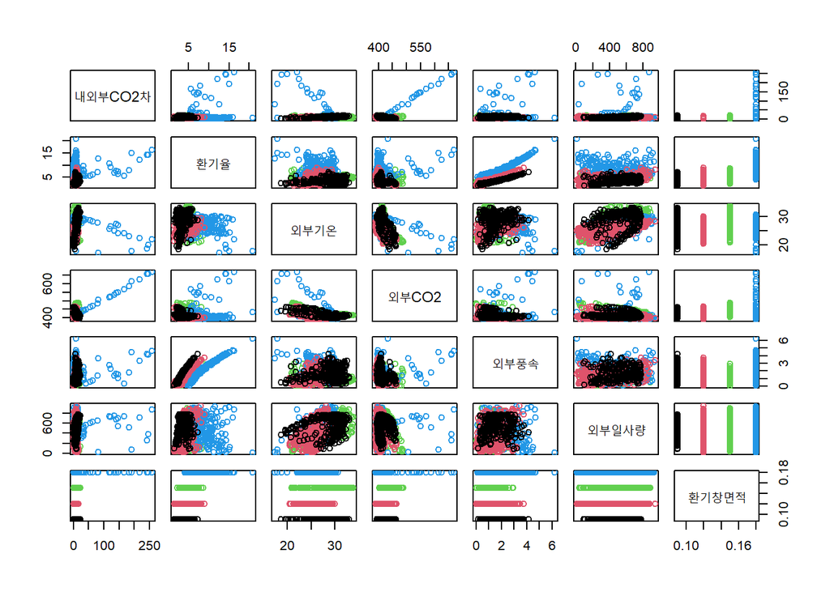

```r
pairs(ex2[1:nrow(plantyes),],col=factor(ex2$환기창면적))
```

- 산점도를 통해 알 수 있는 사실은 외부CO2가 증가할수록 내부CO2가 증가한다는 점이다. 환기창면적과의 교호작용은 뚜렷하게 관측되는 것이 없으나, 외부풍속과의 교호작용의 존재 가능성이 추측된다.

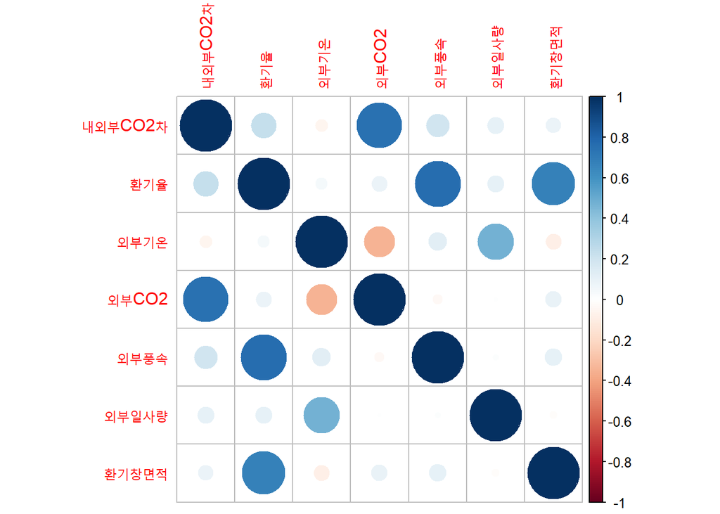

```r
library(corrplot)
corrplot(cor(ex2))
```

- 그리고 각 변수에 대한 기초통계량은 다음과 같이 계산된다.

```r
library(psych)
describe(ex1[,c(-8,-9)])
```

```
##             vars    n   mean     sd median trimmed    mad    min    max  range
## 내외부CO2차    1 1055  10.99  20.50   8.70    8.54   5.93   0.00 258.20 258.20
## 환기율         2 1055   5.15   2.58   4.60    4.77   2.08   1.40  20.90  19.50
## 외부기온       3 1055  26.91   2.99  26.90   26.94   3.26  17.30  33.90  16.60
## 외부CO2        4 1055 414.52  25.67 409.00  410.10  11.12 389.50 669.50 280.00
## 외부풍속       5 1055   1.50   0.92   1.30    1.41   0.83   0.00   6.22   6.21
## 외부일사량     6 1055 459.27 225.19 459.20  460.76 275.02  10.04 950.00 939.96
## 환기창면적     7 1055   0.13   0.03   0.12    0.13   0.04   0.09   0.18   0.09
##              skew kurtosis   se
## 내외부CO2차  8.41    80.22 0.63
## 환기율       1.62     3.44 0.08
## 외부기온    -0.12    -0.42 0.09
## 외부CO2      5.09    37.41 0.79
## 외부풍속     0.97     0.80 0.03
## 외부일사량  -0.02    -1.02 6.93
## 환기창면적   0.12    -1.38 0.00
```

- 내외부CO2차를 반응변수로 하여 각 변수의 주효과와 환기창면적과의 교호작용을 고려한 다중선형회귀모형을 적합하면 다음과 같다.

```r
m_yes <- lm(내외부CO2차~환기율+외부기온+외부CO2+외부풍속+외부일사량+환기창면적+환기창면적*환기율+환기창면적*외부기온+환기창면적*외부CO2+환기창면적*외부풍속+환기창면적*외부일사량,data=plantyes)
summary(m_yes)
```

```
##
## Call:
## lm(formula = 내외부CO2차 ~ 환기율 + 외부기온 + 외부CO2 + 외부풍속 +
##     외부일사량 + 환기창면적 + 환기창면적 * 환기율 + 환기창면적 *
##     외부기온 + 환기창면적 * 외부CO2 + 환기창면적 * 외부풍속 +
##     환기창면적 * 외부일사량, data = plantyes)
##
## Residuals:
##      Min       1Q   Median       3Q      Max
## -21.1359  -4.3676  -0.1063   3.8165  28.8767
##
## Coefficients:
##                         Estimate Std. Error t value Pr(>|t|)
## (Intercept)            7.996e+02  3.422e+01  23.367  < 2e-16 ***
## 환기율                -1.407e+01  1.441e+00  -9.765  < 2e-16 ***
## 외부기온              -2.030e+00  4.402e-01  -4.611 4.51e-06 ***
## 외부CO2               -1.721e+00  6.343e-02 -27.125  < 2e-16 ***
## 외부풍속               1.104e+01  2.153e+00   5.125 3.54e-07 ***
## 외부일사량             7.579e-03  5.237e-03   1.447    0.148
## 환기창면적            -6.633e+03  2.192e+02 -30.256  < 2e-16 ***
## 환기율:환기창면적      6.540e+01  7.740e+00   8.450  < 2e-16 ***
## 외부기온:환기창면적    1.923e+01  3.314e+00   5.803 8.62e-09 ***
## 외부CO2:환기창면적     1.442e+01  3.826e-01  37.683  < 2e-16 ***
## 외부풍속:환기창면적   -6.381e+00  1.733e+01  -0.368    0.713
## 외부일사량:환기창면적  2.405e-02  3.796e-02   0.634    0.527
## ---
## Signif. codes:  0 '***' 0.001 '**' 0.01 '*' 0.05 '.' 0.1 ' ' 1
##
## Residual standard error: 7.601 on 1043 degrees of freedom
## Multiple R-squared:  0.8639, Adjusted R-squared:  0.8625
## F-statistic: 601.9 on 11 and 1043 DF,  p-value: < 2.2e-16
```

- 모형적합 결과 외부일사량이 유의수준 0.05에서 유의미하지 않았다. 그러므로 이를 변수선택 시 제외해야 할 것으로 보인다. 조정된 결정계수의 값은 $R^2_{adj}=0.8625$이다.
- 그리고 여러 교호작용들 중 t 통계량의 절대값이 가장 큰 외부CO2와 환기창면적 사이의 교호작용을 가장 중요한 교호작용으로 판단할 수 있다.

#### Best subset selection

- 여러 측도들을 이용하여 모형에 포함될 변수를 적절히 선택해 보도록 하겠다.
- 분석 의뢰기관의 요청에 따라 환기율은 제외하고 분석한다.

```r
library(leaps)
ms0 <- regsubsets(내외부CO2차~외부기온+외부CO2+외부풍속+외부일사량+환기창면적+환기창면적*외부기온+환기창면적*외부CO2+환기창면적*외부풍속+환기창면적*외부일사량,data=plantyes,nvmax=9)
ms0.summary <- summary(ms0)
ms0.summary
```

```
## Subset selection object
## Call: regsubsets.formula(내외부CO2차 ~ 외부기온 + 외부CO2 + 외부풍속 +
##     외부일사량 + 환기창면적 + 환기창면적 * 외부기온 + 환기창면적 *
##     외부CO2 + 환기창면적 * 외부풍속 + 환기창면적 * 외부일사량,
##     data = plantyes, nvmax = 9)
## 9 Variables  (and intercept)
##                       Forced in Forced out
## 외부기온                  FALSE      FALSE
## 외부CO2                   FALSE      FALSE
## 외부풍속                  FALSE      FALSE
## 외부일사량                FALSE      FALSE
## 환기창면적                FALSE      FALSE
## 외부기온:환기창면적       FALSE      FALSE
## 외부CO2:환기창면적        FALSE      FALSE
## 외부풍속:환기창면적       FALSE      FALSE
## 외부일사량:환기창면적     FALSE      FALSE
## 1 subsets of each size up to 9
## Selection Algorithm: exhaustive
##          외부기온 외부CO2 외부풍속 외부일사량 환기창면적 외부기온:환기창면적
## 1  ( 1 ) " "      "*"     " "      " "        " "        " "
## 2  ( 1 ) " "      " "     " "      " "        "*"        " "
## 3  ( 1 ) " "      "*"     " "      " "        "*"        " "
## 4  ( 1 ) " "      "*"     " "      " "        "*"        " "
## 5  ( 1 ) " "      "*"     " "      " "        "*"        "*"
## 6  ( 1 ) "*"      "*"     " "      " "        "*"        "*"
## 7  ( 1 ) " "      "*"     "*"      " "        "*"        "*"
## 8  ( 1 ) "*"      "*"     "*"      " "        "*"        "*"
## 9  ( 1 ) "*"      "*"     "*"      "*"        "*"        "*"
##          외부CO2:환기창면적 외부풍속:환기창면적 외부일사량:환기창면적
## 1  ( 1 ) " "                " "                 " "
## 2  ( 1 ) "*"                " "                 " "
## 3  ( 1 ) "*"                " "                 " "
## 4  ( 1 ) "*"                "*"                 " "
## 5  ( 1 ) "*"                "*"                 " "
## 6  ( 1 ) "*"                "*"                 " "
## 7  ( 1 ) "*"                "*"                 "*"
## 8  ( 1 ) "*"                "*"                 "*"
## 9  ( 1 ) "*"                "*"                 "*"
```

```r
par(mfrow=c(2,2))
# RSS=SSE
plot(ms0.summary$rss,xlab="Number of Variables",ylab="RSS",type="l")
# Adj R^2
plot(ms0.summary$adjr2,xlab="Number of Variables",ylab="Adjusted RSq",type="l")
which.max(ms0.summary$adjr2)
```

```
## [1] 8
```

```r
points(which.max(ms0.summary$adjr2)
,ms0.summary$adjr2[which.max(ms0.summary$adjr2)
], col="red",cex=2,pch=20)
# Cp
plot(ms0.summary$cp,xlab="Number of Variables",ylab="Cp",type='l')
which.min(ms0.summary$cp)
```

```
## [1] 8
```

```r
points(which.min(ms0.summary$cp)
,ms0.summary$cp[which.min(ms0.summary$cp)
],col="red",cex=2,pch=20)
# BIC
plot(ms0.summary$bic,xlab="Number of Variables",ylab="BIC",type='l')
which.min(ms0.summary$bic)
```

```
## [1] 8
```

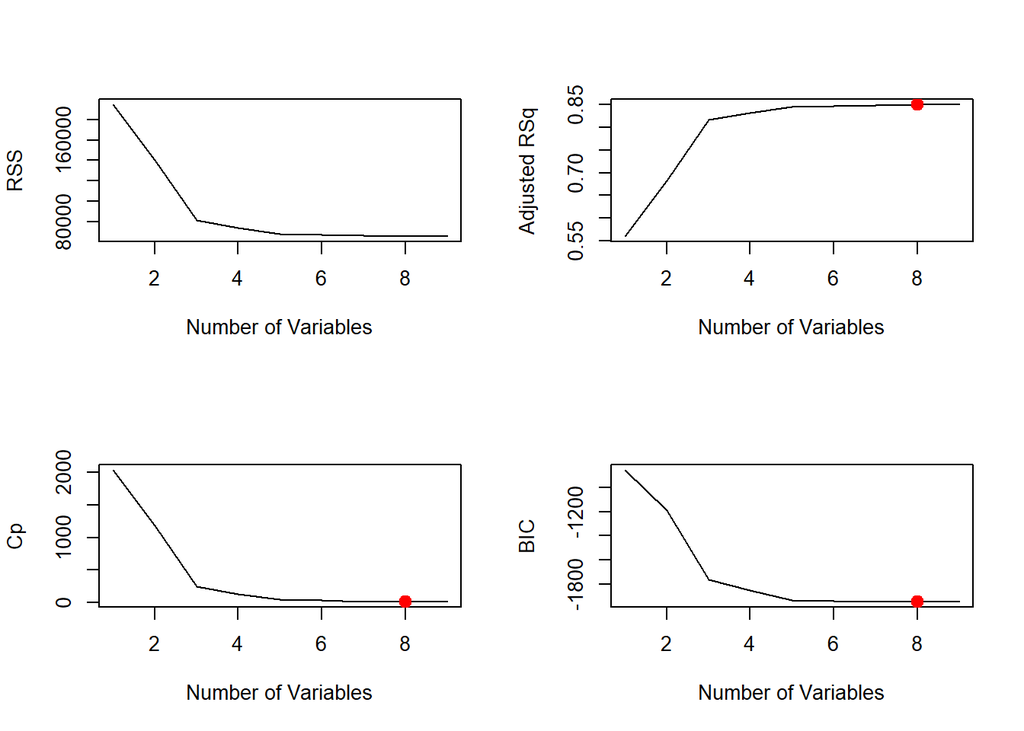

```r
points(which.min(ms0.summary$bic)
,ms0.summary$bic[which.min(ms0.summary$bic)
],col="red",cex=2,pch=20)
```

```r
par(mfrow=c(1,1))
```

```r
library(leaps)
ms0 <- regsubsets(내외부CO2차~외부기온+외부CO2+환기창면적+환기창면적*외부기온+환기창면적*외부CO2,data=plantyes,nvmax=5)
ms0.summary <- summary(ms0)
ms0.summary
```

```
## Subset selection object
## Call: regsubsets.formula(내외부CO2차 ~ 외부기온 + 외부CO2 + 환기창면적 +
##     환기창면적 * 외부기온 + 환기창면적 * 외부CO2, data = plantyes,
##     nvmax = 5)
## 5 Variables  (and intercept)
##                     Forced in Forced out
## 외부기온                FALSE      FALSE
## 외부CO2                 FALSE      FALSE
## 환기창면적              FALSE      FALSE
## 외부기온:환기창면적     FALSE      FALSE
## 외부CO2:환기창면적      FALSE      FALSE
## 1 subsets of each size up to 5
## Selection Algorithm: exhaustive
##          외부기온 외부CO2 환기창면적 외부기온:환기창면적 외부CO2:환기창면적
## 1  ( 1 ) " "      "*"     " "        " "                 " "
## 2  ( 1 ) " "      " "     "*"        " "                 "*"
## 3  ( 1 ) " "      "*"     "*"        " "                 "*"
## 4  ( 1 ) " "      "*"     "*"        "*"                 "*"
## 5  ( 1 ) "*"      "*"     "*"        "*"                 "*"
```

```r
par(mfrow=c(2,2))
# RSS=SSE
plot(ms0.summary$rss,xlab="Number of Variables",ylab="RSS",type="l")
# Adj R^2
plot(ms0.summary$adjr2,xlab="Number of Variables",ylab="Adjusted RSq",type="l")
which.max(ms0.summary$adjr2)
```

```
## [1] 5
```

```r
points(which.max(ms0.summary$adjr2)
,ms0.summary$adjr2[which.max(ms0.summary$adjr2)
], col="red",cex=2,pch=20)
# Cp
plot(ms0.summary$cp,xlab="Number of Variables",ylab="Cp",type='l')
which.min(ms0.summary$cp)
```

```
## [1] 5
```

```r
points(which.min(ms0.summary$cp)
,ms0.summary$cp[which.min(ms0.summary$cp)
],col="red",cex=2,pch=20)
# BIC
plot(ms0.summary$bic,xlab="Number of Variables",ylab="BIC",type='l')
which.min(ms0.summary$bic)
```

```
## [1] 4
```

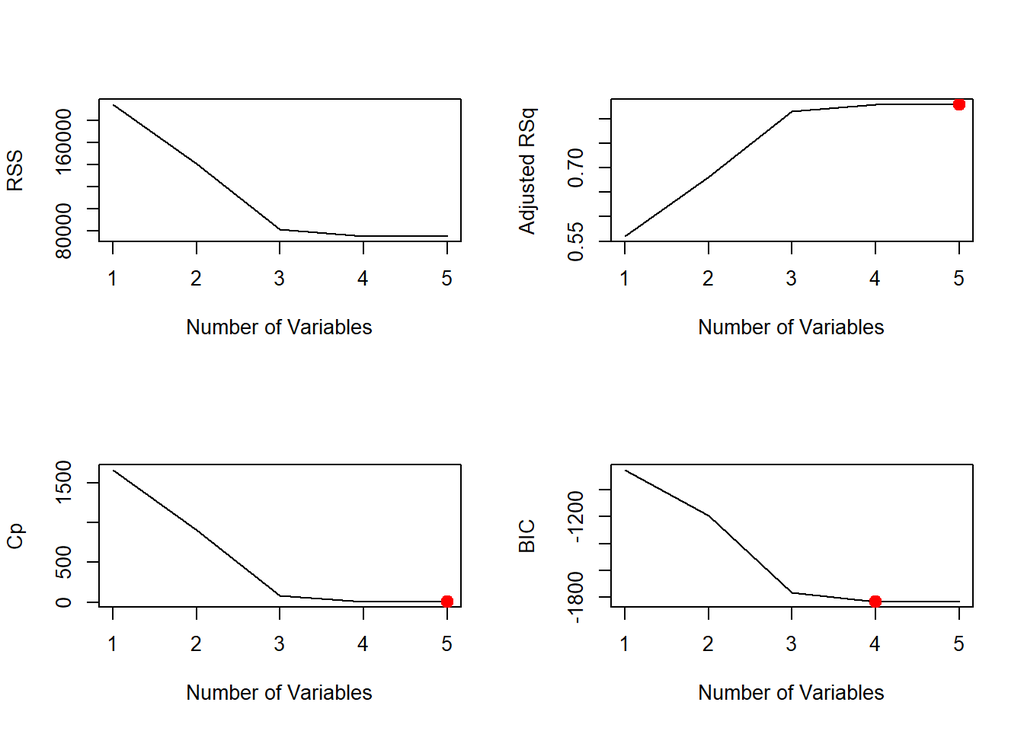

```r
points(which.min(ms0.summary$bic)
,ms0.summary$bic[which.min(ms0.summary$bic)
],col="red",cex=2,pch=20)
```

```r
par(mfrow=c(1,1))
```

- 분석결과 $R_{adj}^2$의 경우는 변수의 개수 5인 모형, $Cp$의 경우는 변수의 개수 5인 모형, 그리고 $BIC$의 경우는 변수의 개수 4인 모형을 최적으로 판단하고 있다. 이들 중 가장 단순한 모형인 변수의 개수 4인 모형을 최종적으로 선택하도록 한다. 모형이 복잡하다고 해서 항상 좋은 예측력을 보인다는 보장이 없고 간단한 모형이 해석하기에는 더 좋기 때문이다.

#### 교차타당검증에 의한 모형 비교

- 지금부터는 train:test=7:3 으로 데이터를 나누어서 몇 개의 후보 모형들의 test RMSE를 계산하여 보겠다. 이 값이 작을수록 예측력이 우수한 모형이라고 볼 수 있다.
- 먼저 데이터를 임의로 train:test=7:3 의 비율로 나눈다. train data는 모형구축 시, test data는 구축된 모형을 평가 시 사용한다.

```r
set.seed(5790)
train.index <- sample(1:nrow(plantyes), round(nrow(plantyes)*7/10), replace=F)
ex1_train <- plantyes[train.index,]
ex1_test <- plantyes[-train.index,]
```

```r
# 모든 주효과, 그리고 환기창면적과 다른 변수들 사이의 교호작용을 포함한 모형
m0 <- lm(내외부CO2차~환기율+외부기온+외부CO2+외부풍속+외부일사량+환기창면적+환기창면적*환기율+환기창면적*외부기온+환기창면적*외부CO2+환기창면적*외부풍속+환기창면적*외부일사량,data=ex1_train)
y_hat0 <- predict(m0,ex1_test)
RMSE0 <- mean(sum((ex1_test$내외부CO2차-y_hat0)^2))
RMSE0
```

```
## [1] 18533.17
```

```r
# Adj R^2, Cp, BIC 등의 기준을 통해 선택된 모형
m0 <- lm(내외부CO2차~외부기온+외부CO2+환기창면적+환기창면적*외부기온+환기창면적*외부CO2,data=ex1_train)
y_hat0 <- predict(m0,ex1_test)
RMSE1 <- mean(sum((ex1_test$내외부CO2차-y_hat0)^2))
RMSE1
```

```
## [1] 22999.78
```

```r
# 모든 주효과와 가장 중요한 교호작용 1가지를 포함한 모형 (분석 의뢰기관의 요청에 따라 환기율은 제외)
m0 <- lm(내외부CO2차~외부기온+외부CO2+외부풍속+외부일사량+환기창면적+환기창면적*외부CO2,data=ex1_train)
y_hat0 <- predict(m0,ex1_test)
RMSE2 <- mean(sum((ex1_test$내외부CO2차-y_hat0)^2))
RMSE2
```

```
## [1] 22114.26
```

- 결과적으로 모든 주효과, 그리고 환기창면적과 다른 변수들 사이의 교호작용을 포함한 모형이 가장 우수하였다.

```r
summary(lm(내외부CO2차~환기율+외부기온+외부CO2+외부풍속+외부일사량+환기창면적+환기창면적*환기율+환기창면적*외부기온+환기창면적*외부CO2+환기창면적*외부풍속+환기창면적*외부일사량,data=ex1_train))
```

```
##
## Call:
## lm(formula = 내외부CO2차 ~ 환기율 + 외부기온 + 외부CO2 + 외부풍속 +
##     외부일사량 + 환기창면적 + 환기창면적 * 환기율 + 환기창면적 *
##     외부기온 + 환기창면적 * 외부CO2 + 환기창면적 * 외부풍속 +
##     환기창면적 * 외부일사량, data = ex1_train)
##
## Residuals:
##      Min       1Q   Median       3Q      Max
## -21.0436  -4.3573  -0.2233   3.7610  28.4849
##
## Coefficients:
##                         Estimate Std. Error t value Pr(>|t|)
## (Intercept)            7.918e+02  4.141e+01  19.123  < 2e-16 ***
## 환기율                -1.168e+01  1.776e+00  -6.581 8.97e-11 ***
## 외부기온              -1.916e+00  5.382e-01  -3.561 0.000393 ***
## 외부CO2               -1.709e+00  7.657e-02 -22.317  < 2e-16 ***
## 외부풍속               8.664e+00  2.612e+00   3.317 0.000955 ***
## 외부일사량             6.262e-03  6.422e-03   0.975 0.329819
## 환기창면적            -6.628e+03  2.633e+02 -25.175  < 2e-16 ***
## 환기율:환기창면적      5.659e+01  9.420e+00   6.007 2.98e-09 ***
## 외부기온:환기창면적    1.896e+01  4.037e+00   4.696 3.17e-06 ***
## 외부CO2:환기창면적     1.438e+01  4.592e-01  31.320  < 2e-16 ***
## 외부풍속:환기창면적   -2.594e+00  2.056e+01  -0.126 0.899626
## 외부일사량:환기창면적  2.126e-02  4.602e-02   0.462 0.644255
## ---
## Signif. codes:  0 '***' 0.001 '**' 0.01 '*' 0.05 '.' 0.1 ' ' 1
##
## Residual standard error: 7.611 on 726 degrees of freedom
## Multiple R-squared:  0.8708, Adjusted R-squared:  0.8688
## F-statistic: 444.7 on 11 and 726 DF,  p-value: < 2.2e-16
```

### 2.3 작물유무 데이터를 합친 경우

#### Multiple Linear Regression Model

- 상관관계에 대한 분석은 작물유무에 따라 데이터를 나누어 분석하는 과정에서 모두 다루었기 때문에 생략하도록 한다.
- 2.1절과 2.2절의 결과를 통해 환기창면적과 환기율, 그리고 환기창면적과 외부CO2 사이의 교호작용이 유의미하다는 사실을 파악할 수 있다.
- 여기에서는 작물유무에 대한 변수가 추가로 들어가고 이에 따라 작물유무에 대한 교호작용을 포함해서 다양한 교호작용 변수를 고려할 수 있지만 모형이 너무 복잡해지므로 바람직하지 않다. 오히려 중요한 교호작용만을 포함한 모형도 충분한 설명력을 가지기 때문이다.
- 따라서 내외부CO2차를 반응변수로 하여 각 변수의 주효과와 환기창면적과 환기율, 그리고 환기창면적과 외부CO2 사이의 교호작용을 포함한 모형을 시작점으로 하여 분석을 진행하도록 한다. 여기에 주효과와 작물유무 사이의 교호작용도 우선 포함한다.

```r
m_total <- lm(내외부CO2차~환기율+외부기온+외부CO2+외부풍속+외부일사량+환기창면적+작물유무+환기창면적*환기율+환기창면적*외부CO2+작물유무*환기율+작물유무*외부기온+작물유무*외부CO2+작물유무*외부풍속+작물유무*외부일사량+작물유무*환기창면적,data=plant)
summary(m_total)
```

```
##
## Call:
## lm(formula = 내외부CO2차 ~ 환기율 + 외부기온 + 외부CO2 + 외부풍속 +
##     외부일사량 + 환기창면적 + 작물유무 + 환기창면적 * 환기율 +
##     환기창면적 * 외부CO2 + 작물유무 * 환기율 + 작물유무 * 외부기온 +
##     작물유무 * 외부CO2 + 작물유무 * 외부풍속 + 작물유무 * 외부일사량 +
##     작물유무 * 환기창면적, data = plant)
##
## Residuals:
##     Min      1Q  Median      3Q     Max
## -56.502  -5.319  -0.305   5.660  39.572
##
## Coefficients:
##                          Estimate Std. Error t value Pr(>|t|)
## (Intercept)             8.761e+02  3.199e+01  27.386  < 2e-16 ***
## 환기율                  1.013e+01  1.352e+00   7.489 1.09e-13 ***
## 외부기온               -6.948e-02  1.850e-01  -0.376  0.70725
## 외부CO2                -1.476e+00  5.689e-02 -25.950  < 2e-16 ***
## 외부풍속               -8.727e+00  9.466e-01  -9.219  < 2e-16 ***
## 외부일사량              9.540e-03  2.359e-03   4.044 5.48e-05 ***
## 환기창면적             -7.460e+03  2.248e+02 -33.184  < 2e-16 ***
## 작물유무yes            -2.552e+02  2.699e+01  -9.456  < 2e-16 ***
## 환기율:환기창면적      -9.375e+00  5.218e+00  -1.797  0.07253 .
## 외부CO2:환기창면적      1.316e+01  4.023e-01  32.717  < 2e-16 ***
## 환기율:작물유무yes     -7.080e+00  1.236e+00  -5.730 1.17e-08 ***
## 외부기온:작물유무yes    6.131e-01  2.291e-01   2.676  0.00751 **
## 외부CO2:작물유무yes    -4.877e-02  5.336e-02  -0.914  0.36085
## 외부풍속:작물유무yes    8.156e+00  1.564e+00   5.215 2.05e-07 ***
## 외부일사량:작물유무yes -7.477e-03  3.038e-03  -2.461  0.01393 *
## 환기창면적:작물유무yes  1.987e+03  6.725e+01  29.550  < 2e-16 ***
## ---
## Signif. codes:  0 '***' 0.001 '**' 0.01 '*' 0.05 '.' 0.1 ' ' 1
##
## Residual standard error: 10.19 on 1774 degrees of freedom
## Multiple R-squared:  0.8764, Adjusted R-squared:  0.8754
## F-statistic: 838.8 on 15 and 1774 DF,  p-value: < 2.2e-16
```

- 모형적합 결과 외부기온이 유의수준 0.05에서 유의미하지 않다. 이는 변수선택 시 제외해야 할 필요가 있다고 보여진다.
- 그리고 가장 중요한 교호작용은 두가지를 선택할 수 있는데 바로 t 통계량의 절대값이 가장 큰 환기창면적과 외부CO2 사이의 교호작용, 그리고 t 통계량의 절대값이 두번째로 큰 작물유무와 환기창면적 사이의 교호작용이라고 판단된다.
- 조정된 결정계수의 값은 $R^2_{adj}=0.8754$이다.

#### Best subset selection

- 여러 측도들을 이용하여 모형에 포함될 변수를 적절히 선택해 보도록 하겠다.
- 분석 의뢰기관의 요청에 따라 환기율은 분석에서 제외한다.

```r
library(leaps)
ms0 <- regsubsets(내외부CO2차~외부기온+외부CO2+외부풍속+외부일사량+환기창면적+작물유무+환기창면적*외부CO2+작물유무*외부기온+작물유무*외부CO2+작물유무*외부풍속+작물유무*외부일사량+작물유무*환기창면적,data=plant,nvmax=12)
ms0.summary <- summary(ms0)
ms0.summary
```

```
## Subset selection object
## Call: regsubsets.formula(내외부CO2차 ~ 외부기온 + 외부CO2 + 외부풍속 +
##     외부일사량 + 환기창면적 + 작물유무 + 환기창면적 * 외부CO2 +
##     작물유무 * 외부기온 + 작물유무 * 외부CO2 + 작물유무 * 외부풍속 +
##     작물유무 * 외부일사량 + 작물유무 * 환기창면적, data = plant,
##     nvmax = 12)
## 12 Variables  (and intercept)
##                        Forced in Forced out
## 외부기온                   FALSE      FALSE
## 외부CO2                    FALSE      FALSE
## 외부풍속                   FALSE      FALSE
## 외부일사량                 FALSE      FALSE
## 환기창면적                 FALSE      FALSE
## 작물유무yes                FALSE      FALSE
## 외부CO2:환기창면적         FALSE      FALSE
## 외부기온:작물유무yes       FALSE      FALSE
## 외부CO2:작물유무yes        FALSE      FALSE
## 외부풍속:작물유무yes       FALSE      FALSE
## 외부일사량:작물유무yes     FALSE      FALSE
## 환기창면적:작물유무yes     FALSE      FALSE
## 1 subsets of each size up to 12
## Selection Algorithm: exhaustive
##           외부기온 외부CO2 외부풍속 외부일사량 환기창면적 작물유무yes
## 1  ( 1 )  " "      "*"     " "      " "        " "        " "
## 2  ( 1 )  " "      " "     " "      " "        " "        "*"
## 3  ( 1 )  " "      " "     " "      " "        " "        "*"
## 4  ( 1 )  " "      " "     " "      " "        "*"        " "
## 5  ( 1 )  " "      "*"     " "      " "        "*"        "*"
## 6  ( 1 )  " "      "*"     " "      " "        "*"        "*"
## 7  ( 1 )  " "      "*"     " "      "*"        "*"        "*"
## 8  ( 1 )  " "      "*"     "*"      "*"        "*"        "*"
## 9  ( 1 )  " "      "*"     "*"      "*"        "*"        "*"
## 10  ( 1 ) " "      "*"     "*"      "*"        "*"        "*"
## 11  ( 1 ) "*"      "*"     "*"      "*"        "*"        "*"
## 12  ( 1 ) "*"      "*"     "*"      "*"        "*"        "*"
##           외부CO2:환기창면적 외부기온:작물유무yes 외부CO2:작물유무yes
## 1  ( 1 )  " "                " "                  " "
## 2  ( 1 )  " "                " "                  "*"
## 3  ( 1 )  "*"                " "                  "*"
## 4  ( 1 )  "*"                " "                  "*"
## 5  ( 1 )  "*"                " "                  " "
## 6  ( 1 )  "*"                " "                  " "
## 7  ( 1 )  "*"                " "                  " "
## 8  ( 1 )  "*"                " "                  " "
## 9  ( 1 )  "*"                "*"                  " "
## 10  ( 1 ) "*"                "*"                  " "
## 11  ( 1 ) "*"                "*"                  " "
## 12  ( 1 ) "*"                "*"                  "*"
##           외부풍속:작물유무yes 외부일사량:작물유무yes 환기창면적:작물유무yes
## 1  ( 1 )  " "                  " "                    " "
## 2  ( 1 )  " "                  " "                    " "
## 3  ( 1 )  " "                  " "                    " "
## 4  ( 1 )  " "                  " "                    "*"
## 5  ( 1 )  " "                  " "                    "*"
## 6  ( 1 )  "*"                  " "                    "*"
## 7  ( 1 )  "*"                  " "                    "*"
## 8  ( 1 )  "*"                  " "                    "*"
## 9  ( 1 )  "*"                  " "                    "*"
## 10  ( 1 ) "*"                  "*"                    "*"
## 11  ( 1 ) "*"                  "*"                    "*"
## 12  ( 1 ) "*"                  "*"                    "*"
```

```r
par(mfrow=c(2,2))
# RSS=SSE
plot(ms0.summary$rss,xlab="Number of Variables",ylab="RSS",type="l")
# Adj R^2
plot(ms0.summary$adjr2,xlab="Number of Variables",ylab="Adjusted RSq",type="l")
which.max(ms0.summary$adjr2)
```

```
## [1] 10
```

```r
points(which.max(ms0.summary$adjr2)
,ms0.summary$adjr2[which.max(ms0.summary$adjr2)
], col="red",cex=2,pch=20)
# Cp
plot(ms0.summary$cp,xlab="Number of Variables",ylab="Cp",type='l')
which.min(ms0.summary$cp)
```

```
## [1] 10
```

```r
points(which.min(ms0.summary$cp)
,ms0.summary$cp[which.min(ms0.summary$cp)
],col="red",cex=2,pch=20)
# BIC
plot(ms0.summary$bic,xlab="Number of Variables",ylab="BIC",type='l')
which.min(ms0.summary$bic)
```

```
## [1] 10
```

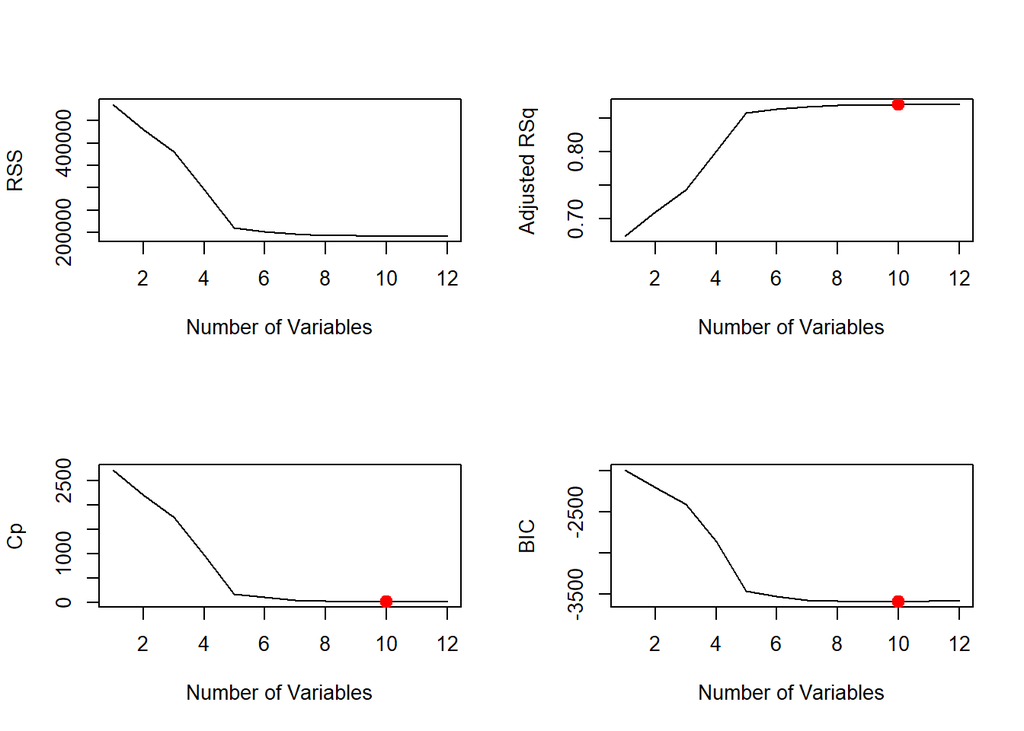

```r
points(which.min(ms0.summary$bic)
,ms0.summary$bic[which.min(ms0.summary$bic)
],col="red",cex=2,pch=20)
```

```r
par(mfrow=c(1,1))
```

- 외부기온을 제외하는 것이 좋다는 결과이다.
- 외부기온을 제외한 모형에 대해서 다시한번 선택해 보자.

```r
library(leaps)
ms0 <- regsubsets(내외부CO2차~외부CO2+외부풍속+외부일사량+환기창면적+작물유무+환기창면적*외부CO2+작물유무*외부CO2+작물유무*외부풍속+작물유무*외부일사량+작물유무*환기창면적,data=plant,nvmax=10)
ms0.summary <- summary(ms0)
ms0.summary
```

```
## Subset selection object
## Call: regsubsets.formula(내외부CO2차 ~ 외부CO2 + 외부풍속 + 외부일사량 +
##     환기창면적 + 작물유무 + 환기창면적 * 외부CO2 + 작물유무 *
##     외부CO2 + 작물유무 * 외부풍속 + 작물유무 * 외부일사량 + 작물유무 *
##     환기창면적, data = plant, nvmax = 10)
## 10 Variables  (and intercept)
##                        Forced in Forced out
## 외부CO2                    FALSE      FALSE
## 외부풍속                   FALSE      FALSE
## 외부일사량                 FALSE      FALSE
## 환기창면적                 FALSE      FALSE
## 작물유무yes                FALSE      FALSE
## 외부CO2:환기창면적         FALSE      FALSE
## 외부CO2:작물유무yes        FALSE      FALSE
## 외부풍속:작물유무yes       FALSE      FALSE
## 외부일사량:작물유무yes     FALSE      FALSE
## 환기창면적:작물유무yes     FALSE      FALSE
## 1 subsets of each size up to 10
## Selection Algorithm: exhaustive
##           외부CO2 외부풍속 외부일사량 환기창면적 작물유무yes 외부CO2:환기창면적
## 1  ( 1 )  "*"     " "      " "        " "        " "         " "
## 2  ( 1 )  " "     " "      " "        " "        "*"         " "
## 3  ( 1 )  " "     " "      " "        " "        "*"         "*"
## 4  ( 1 )  " "     " "      " "        "*"        " "         "*"
## 5  ( 1 )  "*"     " "      " "        "*"        "*"         "*"
## 6  ( 1 )  "*"     " "      " "        "*"        "*"         "*"
## 7  ( 1 )  "*"     " "      "*"        "*"        "*"         "*"
## 8  ( 1 )  "*"     "*"      "*"        "*"        "*"         "*"
## 9  ( 1 )  "*"     "*"      "*"        "*"        "*"         "*"
## 10  ( 1 ) "*"     "*"      "*"        "*"        "*"         "*"
##           외부CO2:작물유무yes 외부풍속:작물유무yes 외부일사량:작물유무yes
## 1  ( 1 )  " "                 " "                  " "
## 2  ( 1 )  "*"                 " "                  " "
## 3  ( 1 )  "*"                 " "                  " "
## 4  ( 1 )  "*"                 " "                  " "
## 5  ( 1 )  " "                 " "                  " "
## 6  ( 1 )  " "                 "*"                  " "
## 7  ( 1 )  " "                 "*"                  " "
## 8  ( 1 )  " "                 "*"                  " "
## 9  ( 1 )  " "                 "*"                  "*"
## 10  ( 1 ) "*"                 "*"                  "*"
##           환기창면적:작물유무yes
## 1  ( 1 )  " "
## 2  ( 1 )  " "
## 3  ( 1 )  " "
## 4  ( 1 )  "*"
## 5  ( 1 )  "*"
## 6  ( 1 )  "*"
## 7  ( 1 )  "*"
## 8  ( 1 )  "*"
## 9  ( 1 )  "*"
## 10  ( 1 ) "*"
```

```r
par(mfrow=c(2,2))
# RSS=SSE
plot(ms0.summary$rss,xlab="Number of Variables",ylab="RSS",type="l")
# Adj R^2
plot(ms0.summary$adjr2,xlab="Number of Variables",ylab="Adjusted RSq",type="l")
which.max(ms0.summary$adjr2)
```

```
## [1] 9
```

```r
points(which.max(ms0.summary$adjr2)
,ms0.summary$adjr2[which.max(ms0.summary$adjr2)
], col="red",cex=2,pch=20)
# Cp
plot(ms0.summary$cp,xlab="Number of Variables",ylab="Cp",type='l')
which.min(ms0.summary$cp)
```

```
## [1] 9
```

```r
points(which.min(ms0.summary$cp)
,ms0.summary$cp[which.min(ms0.summary$cp)
],col="red",cex=2,pch=20)
# BIC
plot(ms0.summary$bic,xlab="Number of Variables",ylab="BIC",type='l')
which.min(ms0.summary$bic)
```

```
## [1] 8
```

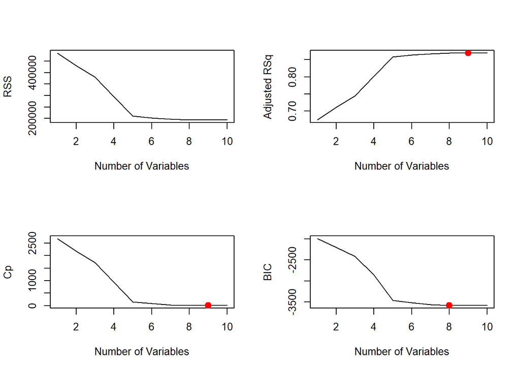

```r
points(which.min(ms0.summary$bic)
,ms0.summary$bic[which.min(ms0.summary$bic)
],col="red",cex=2,pch=20)
```

```r
par(mfrow=c(1,1))
```

- 분석결과 $R_{adj}^2$의 경우는 변수의 개수 9인 모형, $Cp$의 경우는 변수의 개수 9인 모형, 그리고 $BIC$의 경우는 변수의 개수 8인 모형을 최적으로 판단하고 있다. 이에 따라 변수의 개수 8인 모형을 최종적으로 선택하도록 한다. 복잡한 모형이라고 해서 무조건 예측력이 좋다는 보장이 없고 오히려 간단한 모형이 해석하기에는 더 좋기 때문이다.

```r
summary(lm(내외부CO2차~외부CO2+외부풍속+외부일사량+환기창면적+작물유무+환기창면적*외부CO2+작물유무*외부풍속+작물유무*환기창면적,data=plant))
```

```
##
## Call:
## lm(formula = 내외부CO2차 ~ 외부CO2 + 외부풍속 + 외부일사량 +
##     환기창면적 + 작물유무 + 환기창면적 * 외부CO2 + 작물유무 *
##     외부풍속 + 작물유무 * 환기창면적, data = plant)
##
## Residuals:
##     Min      1Q  Median      3Q     Max
## -59.617  -5.303   0.053   5.908  38.727
##
## Coefficients:
##                          Estimate Std. Error t value Pr(>|t|)
## (Intercept)             8.339e+02  2.851e+01  29.254  < 2e-16 ***
## 외부CO2                -1.431e+00  5.302e-02 -26.982  < 2e-16 ***
## 외부풍속               -1.876e+00  3.878e-01  -4.839 1.42e-06 ***
## 외부일사량              9.093e-03  1.206e-03   7.541 7.39e-14 ***
## 환기창면적             -6.853e+03  1.737e+02 -39.446  < 2e-16 ***
## 작물유무yes            -2.403e+02  6.755e+00 -35.569  < 2e-16 ***
## 외부CO2:환기창면적      1.249e+01  3.278e-01  38.116  < 2e-16 ***
## 외부풍속:작물유무yes    4.687e+00  5.109e-01   9.173  < 2e-16 ***
## 환기창면적:작물유무yes  1.681e+03  3.998e+01  42.057  < 2e-16 ***
## ---
## Signif. codes:  0 '***' 0.001 '**' 0.01 '*' 0.05 '.' 0.1 ' ' 1
##
## Residual standard error: 10.43 on 1781 degrees of freedom
## Multiple R-squared:  0.8699, Adjusted R-squared:  0.8693
## F-statistic:  1489 on 8 and 1781 DF,  p-value: < 2.2e-16
```

#### 교차타당검증에 의한 모형 비교

- 지금부터는 train:test=7:3 으로 데이터를 나누어서 몇 개의 후보 모형들의 test RMSE를 계산하여 보겠다. 이 값이 작을수록 예측력이 우수한 모형이라고 볼 수 있다.
- 먼저 데이터를 임의로 train:test=7:3 의 비율로 나눈다. train data는 모형구축 시, test data는 구축된 모형을 평가 시 사용한다.

```r
set.seed(5790)
train.index <- sample(1:nrow(plant), round(nrow(plant)*7/10), replace=F)
ex1_train <- plant[train.index,]
ex1_test <- plant[-train.index,]
```

```r
# 최초로 고려한 모형
m0 <- lm(내외부CO2차~환기율+외부기온+외부CO2+외부풍속+외부일사량+환기창면적+작물유무+환기창면적*환기율+환기창면적*외부CO2+작물유무*환기율+작물유무*외부기온+작물유무*외부CO2+작물유무*외부풍속+작물유무*외부일사량+작물유무*환기창면적,data=ex1_train)
y_hat0 <- predict(m0,ex1_test)
RMSE0 <- mean(sum((ex1_test$내외부CO2차-y_hat0)^2))
RMSE0
```

```
## [1] 55539.19
```

```r
# Adj R^2, Cp, BIC 등의 기준을 바탕으로 선택된 모형 (교호작용이 있는 경우는 주효과 포함)
m0 <- lm(내외부CO2차~외부CO2+외부풍속+외부일사량+환기창면적+작물유무+환기창면적*외부CO2+작물유무*외부풍속+작물유무*환기창면적,data=plant)
y_hat0 <- predict(m0,ex1_test)
RMSE1 <- mean(sum((ex1_test$내외부CO2차-y_hat0)^2))
RMSE1
```

```
## [1] 55062.89
```

```r
# 모든 주효과와 가장 중요한 교호작용 2가지를 포함한 모형
# 분석 의뢰기관의 요청에 따라 환기율은 제외 (이에 따라 환기율을 포함하는 교호작용이면 제외함)
m0 <- lm(내외부CO2차~외부기온+외부CO2+외부풍속+외부일사량+환기창면적+작물유무+환기창면적*외부CO2+작물유무*환기창면적,data=ex1_train)
y_hat0 <- predict(m0,ex1_test)
RMSE2 <- mean(sum((ex1_test$내외부CO2차-y_hat0)^2))
RMSE2
```

```
## [1] 58494.52
```

```r
summary(lm(내외부CO2차~외부CO2+외부풍속+외부일사량+환기창면적+작물유무+환기창면적*외부CO2+작물유무*외부풍속+작물유무*환기창면적,data=ex1_train))
```

```
##
## Call:
## lm(formula = 내외부CO2차 ~ 외부CO2 + 외부풍속 + 외부일사량 +
##     환기창면적 + 작물유무 + 환기창면적 * 외부CO2 + 작물유무 *
##     외부풍속 + 작물유무 * 환기창면적, data = ex1_train)
##
## Residuals:
##     Min      1Q  Median      3Q     Max
## -42.731  -5.304  -0.075   6.154  34.779
##
## Coefficients:
##                          Estimate Std. Error t value Pr(>|t|)
## (Intercept)             8.851e+02  3.474e+01  25.479  < 2e-16 ***
## 외부CO2                -1.526e+00  6.451e-02 -23.650  < 2e-16 ***
## 외부풍속               -2.016e+00  4.733e-01  -4.259 2.21e-05 ***
## 외부일사량              8.440e-03  1.434e-03   5.885 5.11e-09 ***
## 환기창면적             -7.189e+03  2.075e+02 -34.650  < 2e-16 ***
## 작물유무yes            -2.520e+02  8.302e+00 -30.358  < 2e-16 ***
## 외부CO2:환기창면적      1.313e+01  3.913e-01  33.548  < 2e-16 ***
## 외부풍속:작물유무yes    4.673e+00  6.111e-01   7.648 4.08e-14 ***
## 환기창면적:작물유무yes  1.757e+03  4.810e+01  36.521  < 2e-16 ***
## ---
## Signif. codes:  0 '***' 0.001 '**' 0.01 '*' 0.05 '.' 0.1 ' ' 1
##
## Residual standard error: 10.55 on 1244 degrees of freedom
## Multiple R-squared:  0.8772, Adjusted R-squared:  0.8764
## F-statistic:  1111 on 8 and 1244 DF,  p-value: < 2.2e-16
```